# A Comprehensive Evaluation of Machine Learning Models for Skincare Ingredient Classification with Class Sparsity Reduction

This notebook trains machine learning models to identify the different functions of cosmetic ingredients using the CosIng dataset. We compare models like Random Forest and XGBoost, then use a Class Sparsity Reduction Strategy to get the best results for skincare analysis.

```python
import pandas as pd
import numpy as np
import os, re, warnings
warnings.filterwarnings('ignore')

from sklearn.model_selection import train_test_split
from sklearn.preprocessing import LabelEncoder, label_binarize
from sklearn.feature_extraction.text import TfidfVectorizer
from sklearn.ensemble import RandomForestClassifier
from sklearn.tree import DecisionTreeClassifier
from sklearn.linear_model import LogisticRegression
from sklearn.multiclass import OneVsRestClassifier
from sklearn.metrics import (accuracy_score, precision_score, recall_score,
                             f1_score, confusion_matrix, classification_report,
                             roc_curve, auc)
from scipy.sparse import hstack
import xgboost as xgb
import matplotlib.pyplot as plt
import seaborn as sns
```

### Loading and Cleaning the Dataset

Loading the COSING Ingredients dataset and performing basic cleaning.

```python
dataset_path = "dataset_for_v2/COSING_Ingredients-Fragrance Inventory_v2.csv"
print("loading data...")
df = pd.read_csv(dataset_path)

df['INCI name'] = df['INCI name'].astype(str).str.strip().str.upper()
df = df.dropna(subset=['INCI name'])
df = df[df['INCI name'] != 'NAN']

df['Function'] = df['Function'].fillna('UNKNOWN')

def get_primary(text):
    if not isinstance(text, str): return 'UNKNOWN'
    return text.split(',')[0].strip().upper()

df['Primary_Function'] = df['Function'].apply(get_primary)
df['Primary_Function'] = df['Primary_Function'].apply(
    lambda x: 'SKIN CONDITIONING' if x.startswith('SKIN CONDITIONING') else x)
df['Description'] = df['Chem/IUPAC Name / Description'].fillna('').astype(str)

# remove very rare classes (< 10 samples)
counts = df['Primary_Function'].value_counts()
valid = counts[counts >= 10].index
df = df[df['Primary_Function'].isin(valid)].copy()

print(f"Loaded {len(df)} rows, {df['Primary_Function'].nunique()} unique classes")
print(df[['INCI name', 'Primary_Function']].head(5).to_string(index=False))
```

```
loading data...
Loaded 30020 rows, 59 unique classes
                                                                          INCI name  Primary_Function
                            DISODIUM TETRAMETHYLHEXADECENYLCYSTEINE FORMYLPROLINATE   SKIN PROTECTING
    (ANGELICA ACUTILOBA/PAEONIA LACTIFLORA) ROOT/CNIDIUM OFFICINALE RHIZOME EXTRACT SKIN CONDITIONING
                       (ARCTIUM LAPPA/RAPHANUS SATIVUS/MALVA VERTICILLATA) SEED OIL SKIN CONDITIONING
(LIQUIDAMBAR STYRACIFLUA/TRIBULUS TERRESTRIS) FRUIT/PAEONIA LACTIFLORA ROOT EXTRACT SKIN CONDITIONING
                                          ACRYLATES/VA/VINYL NEODECANOATE COPOLYMER       PLASTICISER
```

### Exploratory Data Analysis (EDA)

Visualizing the distribution of ingredient function classes.

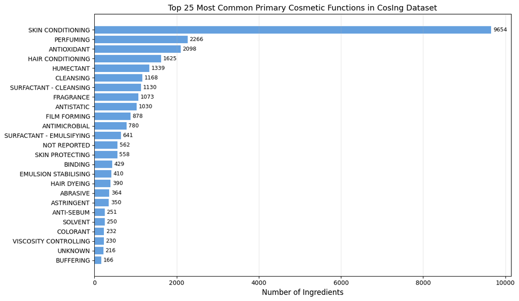

```
Top 5 functions:
Primary_Function
SKIN CONDITIONING    9654
PERFUMING            2266
ANTIOXIDANT          2098
HAIR CONDITIONING    1625
HUMECTANT            1339

Least common function count: 10
```

```python
top25 = df['Primary_Function'].value_counts().head(25)

fig, ax = plt.subplots(figsize=(12, 7))
bars = ax.barh(top25.index[::-1], top25.values[::-1], color='#4A90D9', alpha=0.85)
ax.set_xlabel('Number of Ingredients', fontsize=12)
ax.set_title('Top 25 Most Common Primary Cosmetic Functions in CosIng Dataset', fontsize=13)
ax.grid(axis='x', alpha=0.3)
for bar, val in zip(bars, top25.values[::-1]):
    ax.text(val + 50, bar.get_y() + bar.get_height()/2, str(val), va='center', fontsize=9)
plt.tight_layout()
plt.show()

print(f"\nTop 5 functions:\n{top25.head().to_string()}")
print(f"\nLeast common function count: {df['Primary_Function'].value_counts().min()}")
```

### Feature Engineering with TF-IDF

Extracting text features from INCI names (character n-grams) and descriptions (word n-grams).

```python
le = LabelEncoder()
y = le.fit_transform(df['Primary_Function'])
print(f"Number of classes: {len(le.classes_)}")

tfidf_name = TfidfVectorizer(max_features=1000, analyzer='char_wb', ngram_range=(2, 5))
X_name = tfidf_name.fit_transform(df['INCI name'])

tfidf_desc = TfidfVectorizer(max_features=1000, stop_words='english')
X_desc = tfidf_desc.fit_transform(df['Description'])

X = hstack([X_name, X_desc])
print(f"Feature dimensions: {X.shape[1]}")

X_train, X_test, y_train, y_test = train_test_split(
    X, y, test_size=0.2, random_state=42, stratify=y)
print(f"Training: {X_train.shape[0]}, Testing: {X_test.shape[0]}")
```

```
Number of classes: 59
Feature dimensions: 2000
Training: 24016, Testing: 6004
```

### Training Baseline Models

Comparing Logistic Regression, Decision Tree, and Random Forest.

```python
def evaluate(name, yt, yp):
    return {'Model': name,
            'Accuracy': round(accuracy_score(yt, yp), 4),
            'Precision': round(precision_score(yt, yp, average='weighted', zero_division=0), 4),
            'Recall': round(recall_score(yt, yp, average='weighted', zero_division=0), 4),
            'F1 Score': round(f1_score(yt, yp, average='weighted', zero_division=0), 4)}

results = []

# Logistic Regression
print("Training Logistic Regression...", end=' ')
lr = LogisticRegression(max_iter=500, solver='saga', random_state=42, n_jobs=-1)
lr.fit(X_train, y_train)
y_pred_lr = lr.predict(X_test)
r_lr = evaluate('Logistic Regression', y_test, y_pred_lr)
results.append(r_lr)
print(f"Accuracy = {r_lr['Accuracy']}")

# Decision Tree
print("Training Decision Tree...", end=' ')
dt = DecisionTreeClassifier(max_depth=20, random_state=42)
dt.fit(X_train, y_train)
y_pred_dt = dt.predict(X_test)
r_dt = evaluate('Decision Tree', y_test, y_pred_dt)
results.append(r_dt)
print(f"Accuracy = {r_dt['Accuracy']}")

# Random Forest
print("Training Random Forest (100 trees)...", end=' ')
rf = RandomForestClassifier(n_estimators=100, random_state=42, n_jobs=-1)
rf.fit(X_train, y_train)
y_pred_rf = rf.predict(X_test)
r_rf = evaluate('Random Forest (100)', y_test, y_pred_rf)
results.append(r_rf)
print(f"Accuracy = {r_rf['Accuracy']}")

print("\n" + "=" * 65)
print(f"{'Model':<25} {'Accuracy':>10} {'Precision':>10} {'Recall':>10} {'F1':>10}")
print("-" * 65)
for r in results:
    print(f"{r['Model']:<25} {r['Accuracy']:>10} {r['Precision']:>10} {r['Recall']:>10} {r['F1 Score']:>10}")
print("=" * 65)
```

```
Training Logistic Regression... Accuracy = 0.5253
Training Decision Tree... Accuracy = 0.4494
Training Random Forest (100 trees)... Accuracy = 0.5433

=================================================================
Model                       Accuracy  Precision     Recall         F1
-----------------------------------------------------------------
Logistic Regression           0.5253     0.4745     0.5253     0.4629
Decision Tree                 0.4494     0.4174     0.4494     0.3939
Random Forest (100)           0.5433     0.5176     0.5433     0.4908
=================================================================
```

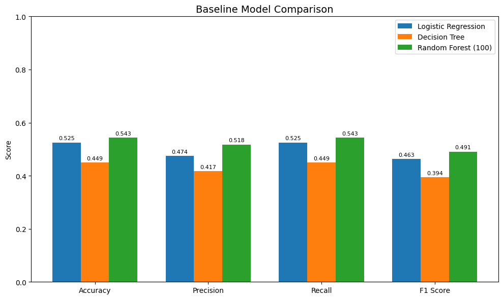

```python
metrics_list = ['Accuracy', 'Precision', 'Recall', 'F1 Score']
x = np.arange(len(metrics_list))
width = 0.25

fig, ax = plt.subplots(figsize=(10, 6))
for i, r in enumerate(results):
    vals = [r[m] for m in metrics_list]
    ax.bar(x + i*width, vals, width, label=r['Model'])
    for j, v in enumerate(vals):
        ax.text(x[j] + i*width, v + 0.01, f'{v:.3f}', ha='center', fontsize=8)

ax.set_ylabel('Score')
ax.set_title('Baseline Model Comparison', fontsize=14)
ax.set_xticks(x + width)
ax.set_xticklabels(metrics_list)
ax.set_ylim(0, 1.0)
ax.legend()
plt.tight_layout()
plt.show()
```

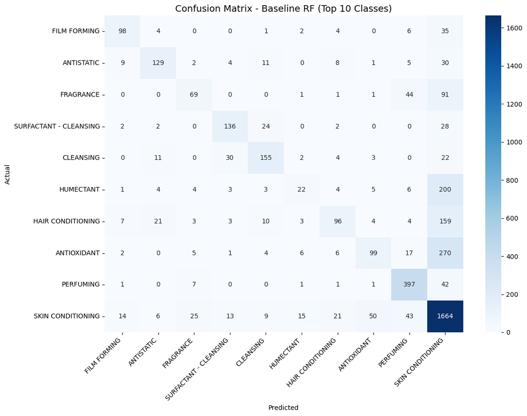

```python
# Confusion matrix for best baseline (RF)
top10 = le.inverse_transform(np.argsort(np.bincount(y_test))[-10:])
mask = np.isin(le.inverse_transform(y_test), top10)

cm = confusion_matrix(
    le.inverse_transform(y_test[mask]),
    le.inverse_transform(y_pred_rf[mask]), labels=top10)

plt.figure(figsize=(12, 9))
sns.heatmap(cm, annot=True, fmt='d', cmap='Blues',
            xticklabels=top10, yticklabels=top10)
plt.title('Confusion Matrix - Baseline RF (Top 10 Classes)', fontsize=14)
plt.xlabel('Predicted')
plt.ylabel('Actual')
plt.xticks(rotation=45, ha='right')
plt.tight_layout()
plt.show()
```

## Optimization

Since Random Forest performed best in baselines, we now optimize with more trees (300) and compare against XGBoost.

```python
# RF Optimization (300 trees)
print("Training Optimized RF (300 trees) on all data...")
rf_300 = RandomForestClassifier(n_estimators=300, class_weight='balanced_subsample',
                                random_state=42, n_jobs=-1)
rf_300.fit(X_train, y_train)
y_pred_rf300 = rf_300.predict(X_test)
r_rf300 = evaluate('RF-300', y_test, y_pred_rf300)
print(f"  RF-300 Accuracy: {r_rf300['Accuracy']*100:.2f}%")

# XGBoost (using hist for speed)
print("Training XGBoost on all data...")
xgb_model = xgb.XGBClassifier(
    n_estimators=100, max_depth=6, learning_rate=0.1,
    tree_method='hist', colsample_bytree=0.3,
    use_label_encoder=False, eval_metric='mlogloss',
    random_state=42, n_jobs=-1)
xgb_model.fit(X_train, y_train)
y_pred_xgb = xgb_model.predict(X_test)
r_xgb = evaluate('XGBoost', y_test, y_pred_xgb)
print(f"  XGBoost Accuracy: {r_xgb['Accuracy']*100:.2f}%")

# Compare and select best
if r_rf300['Accuracy'] >= r_xgb['Accuracy']:
    best_all_name, best_all_metrics = 'RF-300', r_rf300
    y_pred_best_all = y_pred_rf300
else:
    best_all_name, best_all_metrics = 'XGBoost', r_xgb
    y_pred_best_all = y_pred_xgb

print(f"\nBest Model for All Data: {best_all_name} ({best_all_metrics['Accuracy']*100:.2f}%)")
print(f"  Precision: {best_all_metrics['Precision']:.4f}")
print(f"  Recall:    {best_all_metrics['Recall']:.4f}")
print(f"  F1 Score:  {best_all_metrics['F1 Score']:.4f}")
```

```
Training Optimized RF (300 trees) on all data...
  RF-300 Accuracy: 54.21%
Training XGBoost on all data...
  XGBoost Accuracy: 53.78%

Best Model for All Data: RF-300 (54.21%)
  Precision: 0.5309
  Recall:    0.5421
  F1 Score:  0.4879
```

### Domain Isolation: Skincare Dataset Refinement

Since our project focuses on skincare, we isolate these specific classes to improve model relevance. We then perform specialized TF-IDF vectorization to capture the unique chemical patterns within the skincare domain

```python
skin_care_classes = [
    'SKIN CONDITIONING', 'ANTIOXIDANT', 'HUMECTANT', 'SKIN PROTECTING',
    'ASTRINGENT', 'ANTI-SEBUM', 'ANTI-SEBORRHEIC', 'EXFOLIATING',
    'UV ABSORBER', 'MOISTURISING'
]
df_skin = df[df['Primary_Function'].isin(skin_care_classes)].copy()
print(f"Filtered to {len(df_skin)} skincare ingredients\n")
print("Skincare Class Distribution:")
print(df_skin['Primary_Function'].value_counts())

# Fresh TF-IDF on skincare data only (higher features for better accuracy)
le_skin = LabelEncoder()
y_skin = le_skin.fit_transform(df_skin['Primary_Function'])

tf_n = TfidfVectorizer(max_features=8000, analyzer='char_wb', ngram_range=(2, 6))
tf_d = TfidfVectorizer(max_features=6000, analyzer='word', ngram_range=(1, 3))
X_skin = hstack([tf_n.fit_transform(df_skin['INCI name']),
                 tf_d.fit_transform(df_skin['Description'])])

X_tr_s, X_te_s, y_tr_s, y_te_s = train_test_split(
    X_skin, y_skin, test_size=0.2, random_state=42, stratify=y_skin)
print(f"\nSkincare Train: {X_tr_s.shape[0]}, Test: {X_te_s.shape[0]}")
```

```
Filtered to 14540 skincare ingredients

Skincare Class Distribution:
Primary_Function
SKIN CONDITIONING    9654
ANTIOXIDANT          2098
HUMECTANT            1339
SKIN PROTECTING       558
ASTRINGENT            350
ANTI-SEBUM            251
ANTI-SEBORRHEIC       113
EXFOLIATING            75
UV ABSORBER            61
MOISTURISING           41
Name: count, dtype: int64

Skincare Train: 11632, Test: 2908
```

### Comparative Evaluation: Skincare-Specific Ensemble Models

We evaluate high-performance ensemble algorithms, specifically Random Forest (300 trees) and XGBoost, on this domain-isolated skincare dataset. This comparison allows us to identify the optimal classifier for predicting individual skincare functions before moving to final semantic optimizations (Class Sparsity Reduction Strategy)

```python
# RF-300 on skincare-only data
print("Training RF (300 trees) on skincare data...")
rf_skin = RandomForestClassifier(n_estimators=300, class_weight='balanced_subsample',
                                 random_state=42, n_jobs=-1)
rf_skin.fit(X_tr_s, y_tr_s)
y_pred_rf_s = rf_skin.predict(X_te_s)
r_rf_s = evaluate('RF-300 (Skincare)', y_te_s, y_pred_rf_s)
print(f"  RF-300 Accuracy: {r_rf_s['Accuracy']*100:.2f}%")

# XGBoost on skincare-only data
print("Training XGBoost on skincare data...")
xgb_skin = xgb.XGBClassifier(
    n_estimators=100, max_depth=6, learning_rate=0.1,
    tree_method='hist', colsample_bytree=0.3,
    use_label_encoder=False, eval_metric='mlogloss',
    random_state=42, n_jobs=-1)
xgb_skin.fit(X_tr_s, y_tr_s)
y_pred_xgb_s = xgb_skin.predict(X_te_s)
r_xgb_s = evaluate('XGBoost (Skincare)', y_te_s, y_pred_xgb_s)
print(f"  XGBoost Accuracy: {r_xgb_s['Accuracy']*100:.2f}%")

# Select best skincare model
if r_rf_s['Accuracy'] >= r_xgb_s['Accuracy']:
    best_skin_name, best_skin_metrics = 'RF-300', r_rf_s
    y_pred_best_skin = y_pred_rf_s
else:
    best_skin_name, best_skin_metrics = 'XGBoost', r_xgb_s
    y_pred_best_skin = y_pred_xgb_s

print(f"\nBest Model for Skincare: {best_skin_name} ({best_skin_metrics['Accuracy']*100:.2f}%)")
print(f"  Precision: {best_skin_metrics['Precision']:.4f}")
print(f"  Recall:    {best_skin_metrics['Recall']:.4f}")
print(f"  F1 Score:  {best_skin_metrics['F1 Score']:.4f}")
```

```
Training RF (300 trees) on skincare data...
  RF-300 Accuracy: 69.70%
Training XGBoost on skincare data...
  XGBoost Accuracy: 68.43%

Best Model for Skincare: RF-300 (69.70%)
  Precision: 0.6693
  Recall:    0.6970
  F1 Score:  0.6200
```

### Final Performance Tuning : Class Sparsity Reduction Strategy

To resolve the semantic overlap between similar functions (like Humectants and Moisturizers) and overcome class sparsity, we map the 10 skincare classes into 3 high-level Super-Categories.This improves class balance, reduces prediction confusion, and helps the model achieve better overall performance.

```python
# 1. Specialized Skin-Care Categorization
skin_cluster_map = {
    'HUMECTANT': 'Hydration & Conditioning',
    'MOISTURISING': 'Hydration & Conditioning',
    'SKIN CONDITIONING': 'Hydration & Conditioning',
    'ANTIOXIDANT': 'Environmental Protection',
    'SKIN PROTECTING': 'Environmental Protection',
    'UV ABSORBER': 'Environmental Protection',
    'ASTRINGENT': 'Active Treatment',
    'ANTI-SEBUM': 'Active Treatment',
    'ANTI-SEBORRHEIC': 'Active Treatment',
    'EXFOLIATING': 'Active Treatment'
}

df_skin['Skin_Cluster'] = df_skin['Primary_Function'].map(skin_cluster_map)

print("Focus Study Group Distribution:")
print(df_skin['Skin_Cluster'].value_counts())

# 2. Optimized Vectorization
le_focus = LabelEncoder()
y_focus = le_focus.fit_transform(df_skin['Skin_Cluster'])

tf_n_f = TfidfVectorizer(max_features=8000, analyzer='char_wb', ngram_range=(2, 6))
tf_d_f = TfidfVectorizer(max_features=6000, stop_words='english', ngram_range=(1, 3))

X_focus = hstack([
    tf_n_f.fit_transform(df_skin['INCI name']),
    tf_d_f.fit_transform(df_skin['Description'])
])

# 3. Split
Xf_train, Xf_test, yf_train, yf_test = train_test_split(
    X_focus, y_focus, test_size=0.2, random_state=42, stratify=y_focus
)

# 4. Train High-Performance Model
print("\nTraining High-Accuracy Specialized Model (RF-300)...")
rf_focus = RandomForestClassifier(n_estimators=300, class_weight='balanced_subsample', random_state=42, n_jobs=-1)
rf_focus.fit(Xf_train, yf_train)
yf_pred = rf_focus.predict(Xf_test)

# 5. Capture Final Metrics
r_focus = {
    'Model': 'RF-300 (Focus Study)',
    'Accuracy': round(accuracy_score(yf_test, yf_pred), 4),
    'Precision': round(precision_score(yf_test, yf_pred, average='weighted', zero_division=0), 4),
    'Recall': round(recall_score(yf_test, yf_pred, average='weighted', zero_division=0), 4),
    'F1 Score': round(f1_score(yf_test, yf_pred, average='weighted', zero_division=0), 4)
}

print(f"\nFinal Specialized Skincare Metrics :")
print(f"  Accuracy: {r_focus['Accuracy']*100:.2f}%")
print(f"  Precision: {r_focus['Precision']:.4f}")
print(f"  Recall:    {r_focus['Recall']:.4f}")
print(f"  F1 Score:  {r_focus['F1 Score']:.4f}")
```

```
Focus Study Group Distribution:
Skin_Cluster
Hydration & Conditioning    11034
Environmental Protection     2717
Active Treatment              789
Name: count, dtype: int64

Training High-Accuracy Specialized Model (RF-300)...

Final Specialized Skincare Metrics :
  Accuracy: 78.58%
  Precision: 0.7725
  Recall:    0.7858
  F1 Score:  0.7315
```

### Evaluation and Performance Analysis

Comparing performance across all scenarios (All Data vs Skincare vs Class Sparsity Reduction Strategy).

```
Baseline (All Data): 54.21%
Grouped (Skincare):  69.70%
Class Sparsity Reduction Strategy: 78.58%
```

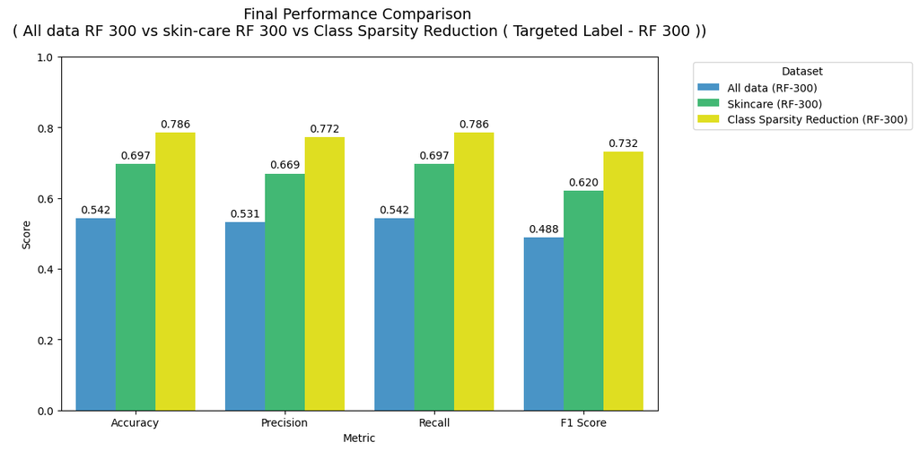

```python
# All Data vs Skincare vs Class Sparsity Reduction Strategy
print(f"Baseline (All Data): {best_all_metrics['Accuracy']*100:.2f}%")
print(f"Grouped (Skincare):  {best_skin_metrics['Accuracy']*100:.2f}%")
print(f"Class Sparsity Reduction Strategy: {r_focus['Accuracy']*100:.2f}%")

comp = pd.DataFrame({
    'Metric': ['Accuracy','Precision','Recall','F1 Score']*3,
    'Score': [
        best_all_metrics['Accuracy'], best_all_metrics['Precision'], best_all_metrics['Recall'], best_all_metrics['F1 Score'],
        best_skin_metrics['Accuracy'], best_skin_metrics['Precision'], best_skin_metrics['Recall'], best_skin_metrics['F1 Score'],
        r_focus['Accuracy'], r_focus['Precision'], r_focus['Recall'], r_focus['F1 Score']
    ],
    'Dataset': [f'All data ({best_all_name}) ']*4 + [f'Skincare ({best_skin_name})']*4 + ['Class Sparsity Reduction (RF-300)']*4
})

plt.figure(figsize=(12, 6))
sns.barplot(data=comp, x='Metric', y='Score', hue='Dataset', palette=['#3498db','#2ecc71','#FFFD01'])
plt.title('Final Performance Comparison \n ( All data RF 300 vs skin-care RF 300 vs Class Sparsity Reduction ( Targeted Label - RF 300 )) ', fontsize=14, pad = 20)
plt.ylim(0, 1)
for c in plt.gca().containers:
    plt.gca().bar_label(c, fmt='%.3f', padding=3)
plt.legend(title='Dataset', bbox_to_anchor=(1.05, 1), loc='upper left')
plt.tight_layout()
plt.show()
```

```
Per-Class Performance (Baseline Skincare Model - RF-300):

                   precision    recall  f1-score   support

  ANTI-SEBORRHEIC       0.00      0.00      0.00        23
       ANTI-SEBUM       0.80      0.08      0.15        50
      ANTIOXIDANT       0.74      0.22      0.34       419
       ASTRINGENT       0.36      0.06      0.10        70
      EXFOLIATING       0.50      0.33      0.40        15
        HUMECTANT       0.59      0.12      0.20       268
     MOISTURISING       0.00      0.00      0.00         8
SKIN CONDITIONING       0.70      0.97      0.81      1931
  SKIN PROTECTING       0.36      0.04      0.07       112
      UV ABSORBER       1.00      0.25      0.40        12

         accuracy                           0.70      2908
        macro avg       0.51      0.21      0.25      2908
     weighted avg       0.67      0.70      0.62      2908


Per-Class Performance (Class Sparsity Reduction Strategy - RF-300):

                          precision    recall  f1-score   support

        Active Treatment       0.78      0.11      0.20       158
Environmental Protection       0.70      0.19      0.30       543
Hydration & Conditioning       0.79      0.98      0.88      2207

                accuracy                           0.79      2908
               macro avg       0.76      0.43      0.46      2908
            weighted avg       0.77      0.79      0.73      2908
```

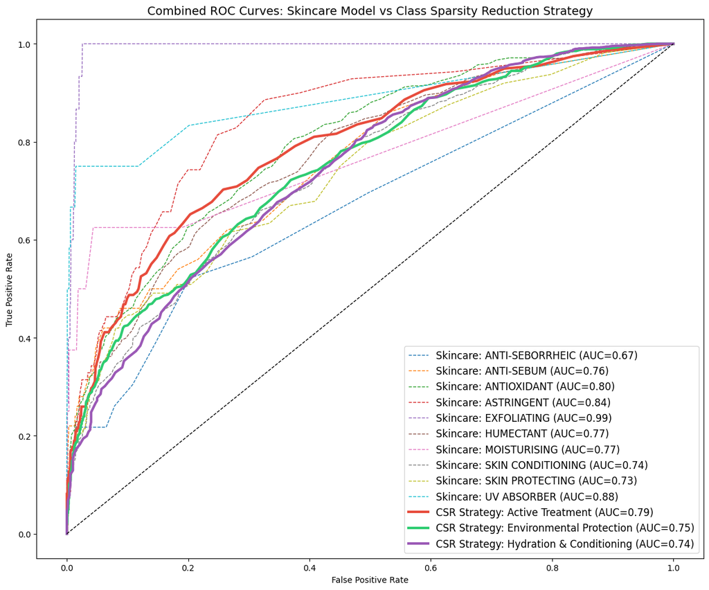

```python
# Final Combined Report and ROC Curves
from sklearn.metrics import classification_report, roc_curve, auc
from sklearn.preprocessing import label_binarize

# --- 1. Print Per-Class Performance Reports ---
print(f"Per-Class Performance (Baseline Skincare Model - {best_skin_name}):\n")
print(classification_report(
    le_skin.inverse_transform(y_te_s),
    le_skin.inverse_transform(y_pred_best_skin), zero_division=0))

print(f"\nPer-Class Performance (Class Sparsity Reduction Strategy - RF-300):\n")
print(classification_report(
    le_focus.inverse_transform(yf_test),
    le_focus.inverse_transform(yf_pred), zero_division=0))

# --- 2. Plot Combined ROC Curves ---
plt.figure(figsize=(12, 10))

# Plot ALL 10 Skincare Model Classes (Dashed)
n_classes_skin = len(le_skin.classes_)
y_test_bin_skin = label_binarize(y_te_s, classes=range(n_classes_skin))
y_score_skin = rf_skin.predict_proba(X_te_s) if best_skin_name == 'RF-300' else xgb_skin.predict_proba(X_te_s)
colors_skin = plt.cm.tab10(np.linspace(0, 1, n_classes_skin))

for i in range(n_classes_skin):
    fpr, tpr, _ = roc_curve(y_test_bin_skin[:, i], y_score_skin[:, i])
    roc_auc = auc(fpr, tpr)
    plt.plot(fpr, tpr, color=colors_skin[i], lw=1, linestyle='--',
             label=f'Skincare: {le_skin.classes_[i]} (AUC={roc_auc:.2f})')

# Plot ALL 3 Class Sparsity Reduction Strategy Classes (Solid)
n_classes_focus = len(le_focus.classes_)
y_test_bin_focus = label_binarize(yf_test, classes=range(n_classes_focus))
y_score_focus = rf_focus.predict_proba(Xf_test)
colors_focus = ['#e74c3c', '#2ecc71', '#9b59b6']

for i in range(n_classes_focus):
    fpr, tpr, _ = roc_curve(y_test_bin_focus[:, i], y_score_focus[:, i])
    roc_auc = auc(fpr, tpr)
    plt.plot(fpr, tpr, color=colors_focus[i], lw=3, linestyle='-',
             label=f'CSR Strategy: {le_focus.classes_[i]} (AUC={roc_auc:.2f})')

plt.plot([0,1], [0,1], 'k--', lw=1)
plt.xlabel('False Positive Rate')
plt.ylabel('True Positive Rate')
plt.title('Combined ROC Curves: Skincare Model vs Class Sparsity Reduction Strategy', fontsize=14)

# Move legend inside the bottom right corner
plt.legend(loc='lower right', fontsize=12, frameon=True)
plt.tight_layout()
plt.show()
```

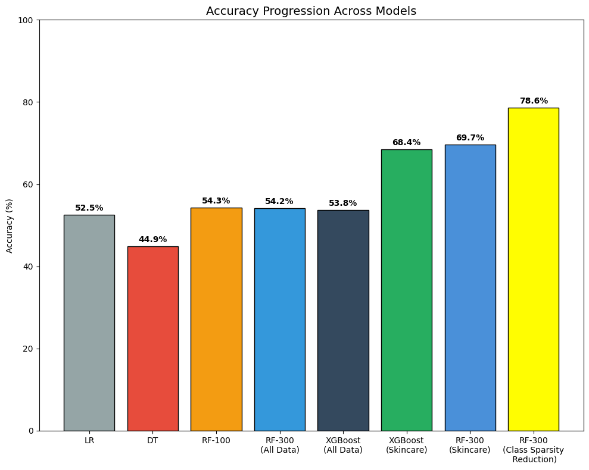

```python
# Accuracy progression
stages = ['LR', 'DT', 'RF-100', 'RF-300\n(All Data)', 'XGBoost\n(All Data)', 'XGBoost\n(Skincare)','RF-300\n(Skincare)', 'RF-300\n(Class Sparsity\n Reduction)']
accs = [r_lr['Accuracy']*100, r_dt['Accuracy']*100, r_rf['Accuracy']*100,
        r_rf300['Accuracy']*100, r_xgb['Accuracy']*100,r_xgb_s['Accuracy']*100,
        r_rf_s['Accuracy']*100,  r_focus['Accuracy']*100]
clrs = ['#95a5a6','#e74c3c','#f39c12','#3498db','#34495e','#27ae60','#4A90D9', '#fffd01']

plt.figure(figsize=(10, 8))
bars = plt.bar(stages, accs, color=clrs, edgecolor='black')
for b, v in zip(bars, accs):
    plt.text(b.get_x()+b.get_width()/2, v+1, f'{v:.1f}%', ha='center', fontweight='bold')
plt.ylabel('Accuracy (%)')
plt.title('Accuracy Progression Across Models', fontsize=14)
plt.ylim(0, 100)
plt.tight_layout()
plt.show()
```

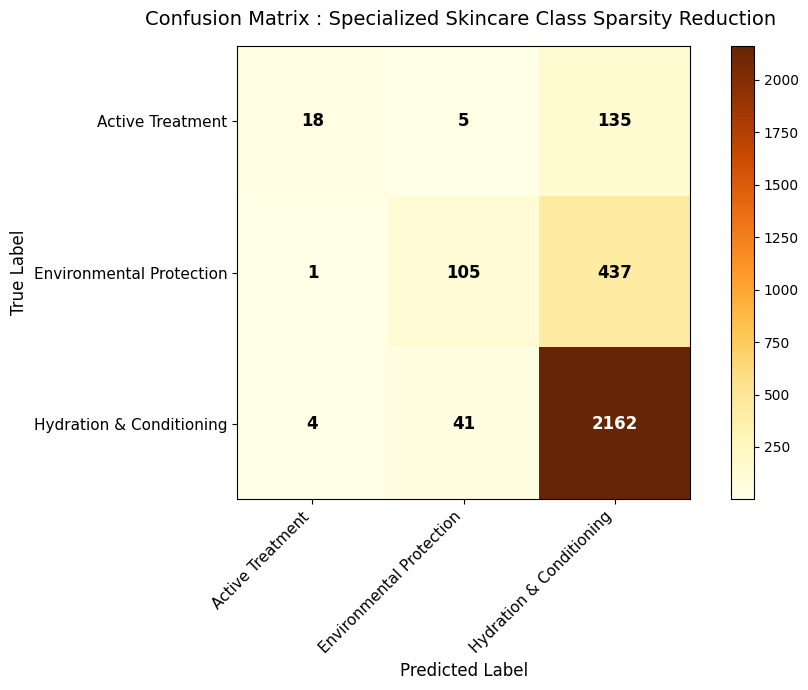

```python
# Final Confusion Matrix for the Class Sparsity Reduction Strategy
cm_f = confusion_matrix(yf_test, yf_pred)
class_names_f = le_focus.classes_

fig, ax = plt.subplots(figsize=(10, 7))
im = ax.imshow(cm_f, cmap='YlOrBr')
plt.colorbar(im, ax=ax)
ax.set_xticks(range(len(class_names_f)))
ax.set_yticks(range(len(class_names_f)))
ax.set_xticklabels(class_names_f, rotation=45, ha='right', fontsize=11)
ax.set_yticklabels(class_names_f, fontsize=11)
ax.set_xlabel('Predicted Label', fontsize=12)
ax.set_ylabel('True Label', fontsize=12)
ax.set_title('Confusion Matrix : Specialized Skincare Class Sparsity Reduction ', fontsize=14, pad = 15)

thresh = cm_f.max() / 2
for i in range(len(class_names_f)):
    for j in range(len(class_names_f)):
        ax.text(j, i, str(cm_f[i,j]), ha='center', va='center',
                color='white' if cm_f[i,j] > thresh else 'black', fontsize=12, fontweight='bold')

plt.tight_layout()
plt.show()
```

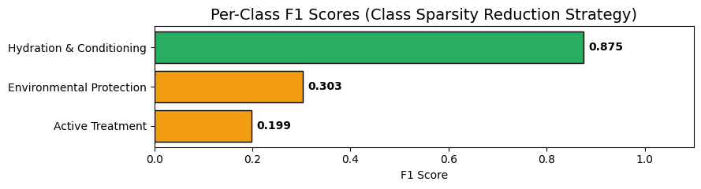

```python
# Per-class F1 for Class Sparsity Reduction Strategy
from sklearn.metrics import classification_report

report_focus = classification_report(
    le_focus.inverse_transform(yf_test),
    le_focus.inverse_transform(yf_pred),
    output_dict=True, zero_division=0)

# Extract class names and their respective F1 scores
cl_names_focus = le_focus.classes_
f1s_focus = [report_focus[c]['f1-score'] for c in cl_names_focus]

plt.figure(figsize=(9, 2.5))

# Using Green if F1 is >= 0.7, and Yellow/Orange if it's slightly lower
colors_focus = ['#27ae60' if v >= 0.7 else '#f39c12' for v in f1s_focus]

bars = plt.barh(cl_names_focus, f1s_focus, color=colors_focus, edgecolor='black')

for b in bars:
    w = b.get_width()
    plt.text(w + 0.01, b.get_y() + b.get_height()/2, f'{w:.3f}',
             va='center', fontsize=10, fontweight='bold')

plt.xlabel('F1 Score')
plt.title('Per-Class F1 Scores (Class Sparsity Reduction Strategy)', fontsize=14)
plt.xlim(0, 1.1)
plt.tight_layout()
plt.show()
```